### Panel Data Approaches

Based on Ethan Addicott’s code

### Prep the panel data

```r
library(plm)
df <- combined.dat2[spp=="Centropristis striata"]
setorder(df, lat.bin, year)

### Create the panel
p.df <- pdata.frame(df, index = c("lat.bin","year"))

### Lag landings by one year (in same lat.bin)
p.df$land_mt.lag.1 <- lag(p.df$land_mt, k = 1)

### Lag biomass by one year
p.df$wtcpuenal.lag.1 <- lag(p.df$wtcpuenal, k = 1)

### Lag presence
p.df$lag1.pres2 <- lag(p.df$pres2, k=1)
```

### Compare lags produced by shift vs plm::lag

```r
head(lag.dt[spp=="Centropristis striata" & lat.bin==40.5,
            list(lag1.land_mt=lag1.land_mt,
                 lag1.wtcpuenal=lag1.wtcpuenal,
                 SBT.actual=SBT.actual,
                 SST.actual=SST.actual,
                 depth=depth,
                 year=year, lat.bin=lat.bin)])
```

```
##    lag1.land_mt lag1.wtcpuenal SBT.actual SST.actual     depth year
## 1:           NA             NA   6.744662   11.36053 104.10092 1968
## 2:    109.90152      -9.210340   7.078953   10.73558  98.35398 1969
## 3:    105.41688      -9.116565   7.138674   11.49763  95.59167 1970
## 4:     94.88243      -9.204564   7.314045   12.39143  93.88148 1971
## 5:     59.71637      -9.200072   9.399390   12.07605  82.27922 1972
## 6:     70.50603      -9.018099   9.635558   13.51511  58.08678 1973
##    lat.bin
## 1:    40.5
## 2:    40.5
## 3:    40.5
## 4:    40.5
## 5:    40.5
## 6:    40.5
```

```r
head(subset(p.df, lat.bin==40.5,
            select=c("land_mt.lag.1", "wtcpuenal.lag.1", "SBT.actual", "SST.actual", "depth","year")))
```

```
##           land_mt.lag.1 wtcpuenal.lag.1 SBT.actual SST.actual     depth
## 40.5-1968            NA              NA   6.744662   11.36053 104.10092
## 40.5-1969     109.90152       -9.210340   7.078953   10.73558  98.35398
## 40.5-1970     105.41688       -9.116565   7.138674   11.49763  95.59167
## 40.5-1971      94.88243       -9.204564   7.314045   12.39143  93.88148
## 40.5-1972      59.71637       -9.200072   9.399390   12.07605  82.27922
## 40.5-1973      70.50603       -9.018099   9.635558   13.51511  58.08678
##           year
## 40.5-1968 1968
## 40.5-1969 1969
## 40.5-1970 1970
## 40.5-1971 1971
## 40.5-1972 1972
## 40.5-1973 1973
```

##### Fixed Effects Panel model

(similar to what I did manually in the previous section of code). Documentation from plm vignette https://cran.r-project.org/web/packages/plm/vignettes/plm.pdf The standard way of estimating fixed effects models with, say, group effects entails transforming the data by subtracting the average over time to every variable, which is usually termed time-demeaning. –> model=“within”“, effect=”individiual" Time effects transforms the data by subtracting the average over the group to every variable= group-demeaning –> model=“within”, effect=“time” Both would be model=“within”, effect=“twoways”

```r
m.fe <- plm(wtcpuenal ~ SBT.actual + SST.actual + depth+ wtcpuenal.lag.1+ land_mt.lag.1, data=p.df, model="within", effect="individual")
summary(m.fe)
```

```
## Oneway (individual) effect Within Model
##
## Call:
## plm(formula = wtcpuenal ~ SBT.actual + SST.actual + depth + wtcpuenal.lag.1 +
##     land_mt.lag.1, data = p.df, effect = "individual", model = "within")
##
## Unbalanced Panel: n = 10, T = 11-46, N = 419
##
## Residuals:
##      Min.   1st Qu.    Median   3rd Qu.      Max.
## -1.765151 -0.230316 -0.040901  0.165326  2.614260
##
## Coefficients:
##                    Estimate  Std. Error t-value Pr(>|t|)
## SBT.actual       0.01439630  0.01613223  0.8924  0.37271
## SST.actual       0.05849925  0.01937907  3.0187  0.00270 **
## depth           -0.00012004  0.00195732 -0.0613  0.95113
## wtcpuenal.lag.1  0.45183030  0.04426374 10.2077  < 2e-16 ***
## land_mt.lag.1   -0.00054333  0.00030658 -1.7722  0.07711 .
## ---
## Signif. codes:  0 '***' 0.001 '**' 0.01 '*' 0.05 '.' 0.1 ' ' 1
##
## Total Sum of Squares:    132.58
## Residual Sum of Squares: 99.258
## R-Squared:      0.25136
## Adj. R-Squared: 0.22541
## F-statistic: 27.1286 on 5 and 404 DF, p-value: < 2.22e-16
```

```r
### Display fixed effects
### Without lagged bio, these were the mean biomass in the lat bin
### With lag.wtcpuenal in the model, these effects are how vary with latitude +/- that predicted from the lagged biomass
fixef(m.fe)
```

```
##      35.5      36.5      37.5      38.5      39.5      40.5      41.5
## -5.945120 -4.904817 -4.872746 -4.909280 -5.273024 -5.508183 -5.476575
##      42.5      43.5      44.5
## -5.634524 -5.656272 -5.544226
```

```r
### Test for serial correlation
pbgtest(m.fe) #outcome there still IS serial correlation even with lag.bio in the model!
```

```
##
##  Breusch-Godfrey/Wooldridge test for serial correlation in panel
##  models
##
## data:  wtcpuenal ~ SBT.actual + SST.actual + depth + wtcpuenal.lag.1 +     land_mt.lag.1
## chisq = 59.948, df = 11, p-value = 9.479e-09
## alternative hypothesis: serial correlation in idiosyncratic errors
```

```r
m.fe.both <- plm(wtcpuenal ~ SBT.actual + SST.actual + depth+ land_mt.lag.1, data=p.df, model="within", effect="twoways")
summary(m.fe.both)
```

```
## Twoways effects Within Model
##
## Call:
## plm(formula = wtcpuenal ~ SBT.actual + SST.actual + depth + land_mt.lag.1,
##     data = p.df, effect = "twoways", model = "within")
##
## Unbalanced Panel: n = 10, T = 11-46, N = 419
##
## Residuals:
##       Min.    1st Qu.     Median    3rd Qu.       Max.
## -1.4257592 -0.3098372 -0.0088328  0.2665001  1.8009974
##
## Coefficients:
##                  Estimate  Std. Error t-value Pr(>|t|)
## SBT.actual    -0.03816404  0.01831203 -2.0841  0.03786 *
## SST.actual     0.04569278  0.02419880  1.8882  0.05980 .
## depth         -0.00789017  0.00277233 -2.8460  0.00468 **
## land_mt.lag.1 -0.00052589  0.00036175 -1.4537  0.14689
## ---
## Signif. codes:  0 '***' 0.001 '**' 0.01 '*' 0.05 '.' 0.1 ' ' 1
##
## Total Sum of Squares:    97.169
## Residual Sum of Squares: 93.595
## R-Squared:      0.036775
## Adj. R-Squared: -0.11841
## F-statistic: 3.43607 on 4 and 360 DF, p-value: 0.0089733
```

##### Create instrumental variables for catch to reduce endogeneity with wtcpue

Create position lags

```r
lats <- unique(p.df$lat.bin)
p.df$land_mt.northlag.1 <- NA
for (i in 1:length(lats) - 1) {
for (j in 1972:2014) {
  north.name <- paste(lats[i + 1],"-",j, sep = "")
  name <- paste(lats[i],"-",j, sep = "")
  if (is.na(as.logical(p.df$land_mt[north.name])) == FALSE & is.na(as.logical(p.df$land_mt[name])) == FALSE) {
  p.df$land_mt.northlag.1[name] <- p.df$land_mt[north.name]
  }
  else if (is.na(as.logical(p.df$land_mt[name])) == FALSE)  {
    p.df$land_mt.northlag.1[name] <- NA
  }
}
}


p.df$land_mt.southlag.1 <- NA
for (i in 2:length(lats)) {
for (j in 1963:2014) {
  south.name <- paste(lats[i - 1],"-",j, sep = "")
  name <- paste(lats[i],"-",j, sep = "")
  if (is.na(as.logical(p.df$land_mt[south.name])) == FALSE & is.na(as.logical(p.df$land_mt[name])) == FALSE) {
  p.df$land_mt.southlag.1[name] <- p.df$land_mt[south.name]
  }
  else if (is.na(as.logical(p.df$land_mt[name])) == FALSE)  {
    p.df$land_mt.southlag.1[name] <- NA
  }
}
}
```

Creates time lags for the position lags (eg nlag.ylag.1 is landings in the north, last year)

```r
p.df$land_mt.nlag.ylag.1 <- lag(p.df$land_mt.northlag.1, k = 1)
p.df$land_mt.nlag.ylag.2 <- lag(p.df$land_mt.northlag.1, k = 2)
p.df$land_mt.slag.ylag.1 <- lag(p.df$land_mt.southlag.1, k = 1)
p.df$land_mt.slag.ylag.2 <- lag(p.df$land_mt.southlag.1, k = 2)
```

##### Include instrumental variables in the fixed effects model

instruments after the |

if the model is y ~x1 + x2 + x3 with x1 and x2 endogenous and z1 and z2 external instruments formula=y~x1+x2+x3 | x3 + z1 + z2 Or equivalently formula=y~x1+x2+x3 | . -x1-x2+z1+z2 (eg subtract out x1 and x1 and add in z1 and z2)

Instrumental variables with twoway fixed effects

```r
m.14 <- plm(wtcpuenal~SBT.actual + SST.actual + depth + land_mt.lag.1 | SBT.actual + SST.actual + depth + land_mt.nlag.ylag.1 + land_mt.slag.ylag.1, data = p.df, model = "within", effect = "twoways")
summary(m.14)
```

```
## Twoways effects Within Model
## Instrumental variable estimation
##
## Call:
## plm(formula = wtcpuenal ~ SBT.actual + SST.actual + depth + land_mt.lag.1 |
##     SBT.actual + SST.actual + depth + land_mt.nlag.ylag.1 + land_mt.slag.ylag.1,
##     data = p.df, effect = "twoways", model = "within")
##
## Unbalanced Panel: n = 8, T = 15-42, N = 308
##
## Residuals:
##      Min.   1st Qu.    Median   3rd Qu.      Max.
## -1.502487 -0.345118 -0.024731  0.311089  1.774956
##
## Coefficients:
##                 Estimate Std. Error z-value Pr(>|z|)
## SBT.actual    -0.0226191  0.0374918 -0.6033  0.54630
## SST.actual     0.0175995  0.0435895  0.4038  0.68639
## depth         -0.0093460  0.0054775 -1.7063  0.08796 .
## land_mt.lag.1 -0.0036112  0.0022698 -1.5910  0.11161
## ---
## Signif. codes:  0 '***' 0.001 '**' 0.01 '*' 0.05 '.' 0.1 ' ' 1
##
## Total Sum of Squares:    69.64
## Residual Sum of Squares: 86.496
## R-Squared:      0.0050865
## Adj. R-Squared: -0.1978
## Chisq: 4.54106 on 4 DF, p-value: 0.33771
```

Instrumental variables with lat bin fixed effect and lagged presence

```r
m.15 <- plm(wtcpuenal~SBT.actual + SST.actual + depth + lag1.pres2 + land_mt.lag.1 | SBT.actual + SST.actual + depth + land_mt.nlag.ylag.1 + land_mt.slag.ylag.1, data = p.df, model = "within", effect = "individual")
summary(m.15)
```

```
## Oneway (individual) effect Within Model
## Instrumental variable estimation
##
## Call:
## plm(formula = wtcpuenal ~ SBT.actual + SST.actual + depth + lag1.pres2 +
##     land_mt.lag.1 | SBT.actual + SST.actual + depth + land_mt.nlag.ylag.1 +
##     land_mt.slag.ylag.1, data = p.df, effect = "individual",
##     model = "within")
##
## Unbalanced Panel: n = 8, T = 15-42, N = 308
##
## Residuals:
##      Min.   1st Qu.    Median   3rd Qu.      Max.
## -3.113363 -0.232422  0.001752  0.239721  3.230633
##
## Coefficients:
##                  Estimate  Std. Error z-value  Pr(>|z|)
## SBT.actual     0.01723513  0.03034044  0.5681   0.57000
## SST.actual     0.06891175  0.03268771  2.1082   0.03501 *
## depth         -0.00029356  0.00368175 -0.0797   0.93645
## lag1.pres2     7.30519226  1.85088711  3.9469 7.918e-05 ***
## land_mt.lag.1 -0.00096858  0.00077802 -1.2449   0.21316
## ---
## Signif. codes:  0 '***' 0.001 '**' 0.01 '*' 0.05 '.' 0.1 ' ' 1
##
## Total Sum of Squares:    101.38
## Residual Sum of Squares: 104.3
## R-Squared:      0.2403
## Adj. R-Squared: 0.2094
## Chisq: 46.0097 on 5 DF, p-value: 9.0411e-09
```

### Using fixed effects in non-plm framework

To recreate fixed effects but potentially use modeling framework other than linear model, make dummy variable for individual effect that is a factor (rather than lat.bin as continuous variable) Example: fixed.dum <-lm(y ~ x1 + factor(country) - 1, data=Panel)

Stack exchange about dealing with autocorrelation https://stats.stackexchange.com/questions/181257/correcting-for-autocorrelation-in-simple-linear-regressions-in-r Change the model specification to obtain non-autocorrelated errors. For example, run a regression with ARMA errors (easy to implement by arima or auto.arima functions in R including the regressors via the parameter xreg) or – as DJohnson suggested – include lags of dependent variable as regressors. So, is having lagged presence (or biomass) sufficient? Potentially can evaluate by plotting bio t against bio t-1

Similar (but not identical) results to m.fe Coefficients for each lat bin very similar to what get with fixef(m.fe)

```r
mod.lbin.dum <- lm(wtcpuenal ~ SBT.actual + SST.actual + depth + lag1.wtcpuenal + lag1.land_mt + lat.bin - 1, data=lag.dt[spp=="Centropristis striata"])

### Using the p.df instead
mod.lbin.dum.p <- lm(wtcpuenal ~ SBT.actual + SST.actual + depth + wtcpuenal.lag.1 + land_mt.lag.1 + lat.bin - 1, data=p.df)



drop1(mod.lbin.dum, test="F")
```

```
## Single term deletions
##
## Model:
## wtcpuenal ~ SBT.actual + SST.actual + depth + lag1.wtcpuenal +
##     lag1.land_mt + lat.bin - 1
##                Df Sum of Sq    RSS     AIC F value  Pr(>F)
## <none>                      102.91 -577.60
## SBT.actual      1     0.004 102.91 -579.58  0.0157 0.90048
## SST.actual      1     2.490 105.40 -569.39  9.9676 0.00171 **
## depth           1     0.007 102.92 -579.57  0.0286 0.86575
## lag1.wtcpuenal  1    24.956 127.86 -486.88 99.9141 < 2e-16 ***
## lag1.land_mt    1     0.846 103.75 -576.10  3.3868 0.06644 .
## lat.bin        10    37.490 140.40 -464.95 15.0094 < 2e-16 ***
## ---
## Signif. codes:  0 '***' 0.001 '**' 0.01 '*' 0.05 '.' 0.1 ' ' 1
```

```r
### Compare with gam
gam.lbin.dum <- gam(wtcpuenal ~ s(SBT.actual) + s(SST.actual) + depth + lag1.wtcpuenal + lag1.land_mt + lat.bin - 1, data=lag.dt[spp=="Centropristis striata"])
```

#### Plot effect using jtools

By default, all numeric predictors other than the one specified in the pred argument are meancentered

```r
mod.cod1 <- lm(wtcpuenal ~ SBT.actual + SST.actual + depth + lag1.land_mt + lag1.land_mt + lat.bin - 1, data=lag.dt[spp=="Gadus morhua" & pres2!=0])

mod.hp1 <- lm(wtcpuenal ~ SBT.actual + SST.actual + depth + lag1.land_mt + lag1.land_mt + lat.bin - 1, data=lag.dt[spp=="Hippoglossoides platessoides" & pres2!=0])

mod.pa1 <- lm(wtcpuenal ~ SBT.actual + SST.actual + depth + lag1.land_mt + lag1.land_mt + lat.bin - 1, data=lag.dt[spp=="Pseudopleuronectes americanus" & pres2!=0])

mod.pm1 <- lm(wtcpuenal ~ SBT.actual + SST.actual + depth + lag1.land_mt + lag1.land_mt + lat.bin - 1, data=lag.dt[spp=="Placopecten magellanicus" & pres2!=0])

mod.lo1 <- lm(wtcpuenal ~ SBT.actual + SST.actual + depth + lag1.land_mt + lag1.land_mt + lat.bin - 1, data=lag.dt[spp=="Leucoraja ocellata" & pres2!=0])

mod.la1 <- lm(wtcpuenal ~ SBT.actual + SST.actual + depth + lag1.land_mt + lag1.land_mt + lat.bin - 1, data=lag.dt[spp=="Lophius americanus" & pres2!=0])

library(jtools)
```

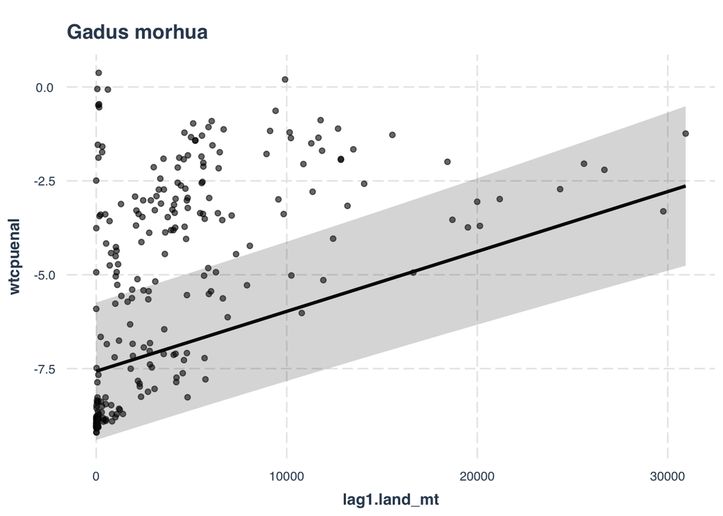

```r
effect_plot(mod.cod1, pred = lag1.land_mt, interval = TRUE, plot.points = TRUE, main.title="Gadus morhua")
```

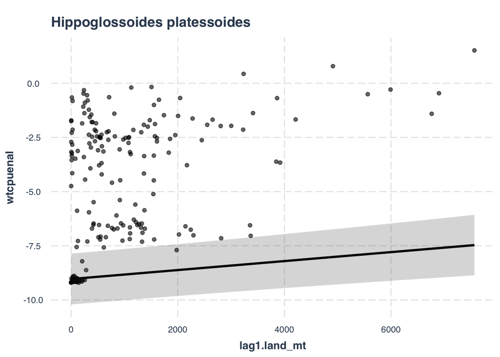

```r
effect_plot(mod.hp1, pred = lag1.land_mt, interval = TRUE, plot.points = TRUE, main.title="Hippoglossoides platessoides")
```

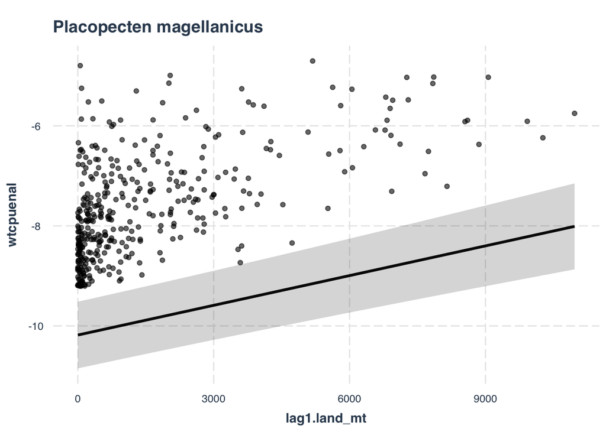

```r
effect_plot(mod.pm1, pred = lag1.land_mt, interval = TRUE, plot.points = TRUE, main.title="Placopecten magellanicus")
```

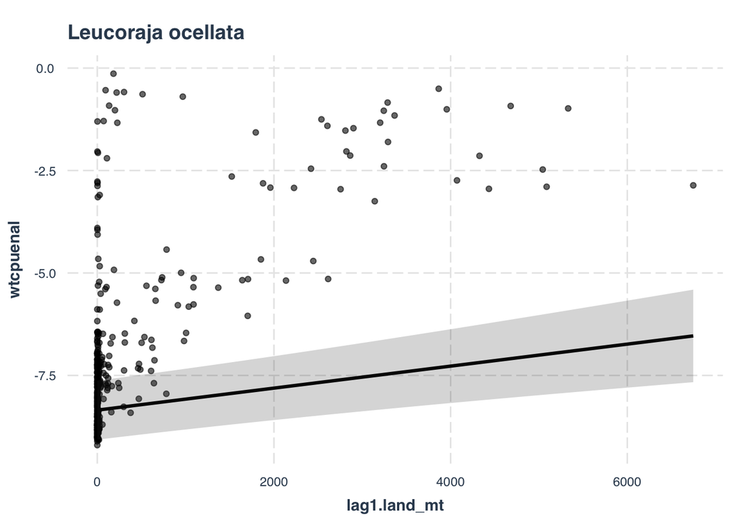

```r
effect_plot(mod.lo1, pred = lag1.land_mt, interval = TRUE, plot.points = TRUE, main.title="Leucoraja ocellata")
```

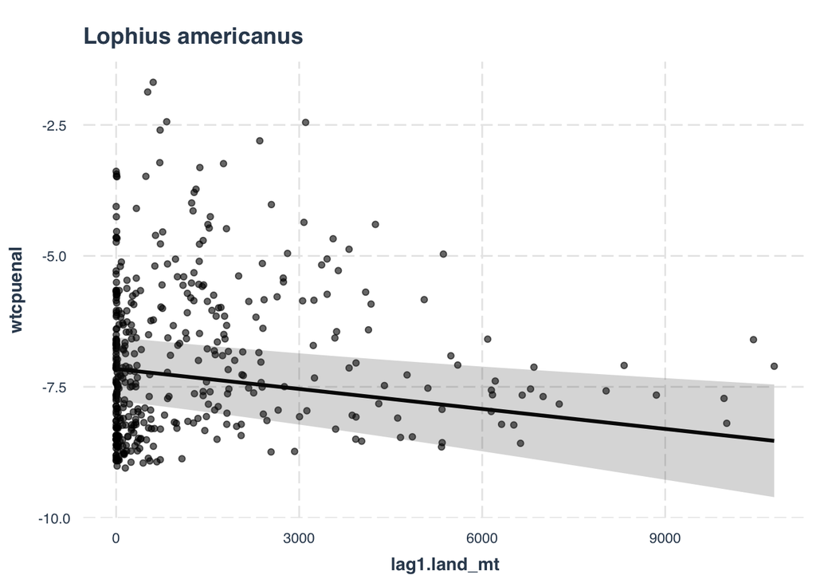

```r
effect_plot(mod.la1, pred = lag1.land_mt, interval = TRUE, plot.points = TRUE, main.title="Lophius americanus")
```